# Housing Permit Data Processing

Derek Ouyang

September 18, 2020

# Load datasets

3 datasets

- “Residential_Building_Permits_(attributes).csv”: the original data that MTC/ABAG collected itself, 2014-2017.
- “Table A2 Report with Data Dictionary (1).xlsx”: the 2019 HCD data that MTC/ABAG hasn’t tried to merge.
- “Housing_APR_Data_Aug2020.csv”: the 2018 HCD data that MTC/ABAG has tried to merge. “Dictionary_Crosswalk.xlsx” includes data dictionary and crosswalk for this process.

Load 2014-2017 data

```r
data1417 <- read_csv(paste0(path,"Residential_Building_Permits_(attributes).csv"))
colnames(data1417)
```

```
##  [1] "objectid"   "joinid"     "permyear"   "county"     "jurisdictn"
##  [6] "apn"        "address"    "zip"        "projname"   "hcategory"
## [11] "vlowdr"     "vlowndr"    "vlowtot"    "lowdr"      "lowndr"
## [16] "lowtot"     "moddr"      "modndr"     "modtot"     "amodtot"
## [21] "totalunit"  "tenure"     "mapped"     "mapnotes"   "pda"
## [26] "pdacycle"   "pdajoinid"  "tpa"        "tpacycle"   "hsngsite"
## [31] "rhnacycle"  "notes"      "ObjectId2"
```

Load in MTC processed data of HCD 2018

```r
data18 <- read_csv(paste0(path,"Housing_APR_Data_Aug2020.csv"))
colnames(data18)
```

```
##  [1] "MTC_ID"                           "MTC_TYPE"
##  [3] "MTC_YEAR"                         "MTC_VLOW_INCOME_DR"
##  [5] "MTC_VLOW_INCOME_NDR"              "MTC_VLOW_TOT"
##  [7] "MTC_LOW_INCOME_DR"                "MTC_LOW_INCOME_NDR"
##  [9] "MTC_LOW_TOT"                      "MTC_MOD_INCOME_DR"
## [11] "MTC_MOD_INCOME_NDR"               "MTC_MOD_TOT"
## [13] "MTC_ABOVE_MOD_INCOME"             "MTC_TOTAL_UNITS"
## [15] "MTC_ISSUE_DT"                     "MTC_NO_OF_UNITS"
## [17] "MTC_GEOCODE_ADDRESS"              "MTC_GEOCODE_TYPE"
## [19] "MTC_MAPPED"                       "MTC_LAT"
## [21] "MTC_LONG"                         "MTC_WKT"
## [23] "MTC_PDA"                          "MTC_TPA"
## [25] "MTC_HOUSING_ELEMENT_SITE"         "MTC_NOTES"
## [27] "JURS_NAME"                        "CNTY_NAME"
## [29] "PRIOR_APN"                        "APN"
```

[output cut: 22 more lines]

Load in crosswalk

```r
excel_sheets(paste0(path,"Dictionary_Crosswalk.xlsx"))
```

```
## [1] "2018 Data Dictionary" "Crosswalk"
```

```r
dictionary18 <- read_excel(paste0(path,"Dictionary_Crosswalk.xlsx"), sheet = "2018 Data Dictionary")
```

```
## * `` -> ...3
```

```r
crosswalk <- read_excel(paste0(path,"Dictionary_Crosswalk.xlsx"), sheet = "Crosswalk")
```

```
## * `` -> ...3
## * `` -> ...4
## * `` -> ...5
```

Load 2018-2019 HCD data (may not be a complete 2018 record, just the records that were “missing” from 2018)

```r
excel_sheets(paste0(path,"Table A2 Report with Data Dictionary (1).xlsx"))
```

```
## [1] "Data Dictionary"     "Table A2 Report"     "Bay Area Extraction"
```

```r
data19full <- read_excel(paste0(path,"Table A2 Report with Data Dictionary (1).xlsx"), sheet = "Table A2 Report")

colnames(data19full)
```

```
##  [1] "JURS_NAME"                   "CNTY_NAME"
##  [3] "YEAR"                        "PRIOR_APN"
##  [5] "APN"                         "STREET_ADDRESS"
##  [7] "PROJECT_NAME"                "JURS_TRACKING_ID"
##  [9] "UNIT_CAT_DESC"               "TENURE"
## [11] "VLOW_INCOME_DR"              "VLOW_INCOME_NDR"
## [13] "LOW_INCOME_DR"               "LOW_INCOME_NDR"
## [15] "MOD_INCOME_DR"               "MOD_INCOME_NDR"
## [17] "ABOVE_MOD_INCOME"            "ENT_APPROVE_DT"
## [19] "NO_ENTITLEMENTS"             "BP_VLOW_INCOME_DR"
## [21] "BP_VLOW_INCOME_NDR"          "BP_LOW_INCOME_DR"
## [23] "BP_LOW_INCOME_NDR"           "BP_MOD_INCOME_DR"
## [25] "BP_MOD_INCOME_NDR"           "BP_ABOVE_MOD_INCOME"
## [27] "BP_ISSUE_DT"                 "NO_BILDING_PERMITS"
## [29] "CO_VLOW_INCOME_DR"           "CO_VLOW_INCOME_NDR"
## [31] "CO_LOW_INCOME_DR"            "CO_LOW_INCOME_NDR"
## [33] "CO_MOD_INCOME_DR"            "CO_MOD_INCOME_NDR"
## [35] "CO_ABOVE_MOD_INCOME"         "CO_ISSUE_DT"
## [37] "NO_OTHER_FORMS_OF_READINESS" "EXTR_LOW_INCOME_UNITS"
## [39] "APPROVE_SB35"                "INFILL_UNITS"
## [41] "FIN_ASSIST_NAME"             "DR_TYPE"
## [43] "NO_FA_DR"                    "TERM_AFF_DR"
## [45] "DEM_DES_UNITS"               "DEM_OR_DES_UNITS"
## [47] "DEM_DES_UNITS_OWN_RENT"      "NOTES"
```

Filter to just Bay Area

```r
unique(data19full$CNTY_NAME)
```

```
##  [1] "SAN BERNARDINO"  "LOS ANGELES"     "ALAMEDA"         "ORANGE"
##  [5] "ALPINE"          "MODOC"           "AMADOR"          "NAPA"
##  [9] "SHASTA"          "CALAVERAS"       "CONTRA COSTA"    "HUMBOLDT"
## [13] "SAN LUIS OBISPO" "KERN"            "SAN MATEO"       "PLACER"
## [17] "KINGS"           "RIVERSIDE"       "MARIN"           "SOLANO"
## [21] "BUTTE"           "INYO"            "IMPERIAL"        "SANTA BARBARA"
## [25] "VENTURA"         "SANTA CLARA"     "SANTA CRUZ"      "SAN DIEGO"
## [29] "STANISLAUS"      "MADERA"          "SACRAMENTO"      "LAKE"
## [33] "SONOMA"          "FRESNO"          "COLUSA"          "TEHAMA"
## [37] "DEL NORTE"       "YOLO"            "TULARE"          "MERCED"
## [41] "SISKIYOU"        "EL DORADO"       "SAN JOAQUIN"     "MENDOCINO"
## [45] "GLENN"           "NEVADA"          "MONTEREY"        "SAN BENITO"
## [49] "SUTTER"          "MONO"            "MARIPOSA"        "YUBA"
## [53] "PLUMAS"          "SAN FRANCISCO"   NA                "TUOLUMNE"
## [57] "LASSEN"          "TRINITY"         "SIERRA"          "0"
```

```r
data19 <-
  data19full %>%
  filter(CNTY_NAME %in% c(
    "ALAMEDA",
    "CONTRA COSTA",
    "MARIN",
    "NAPA",
    "SAN FRANCISCO",
    "SAN MATEO",
    "SANTA CLARA",
    "SOLANO",
    "SONOMA"
  ))
```

data1417: 27009 rows data18: 35926 rows data19: 30864 rows

# Understanding existing match

I would expect all of data1417 to have been merged into data18

```r
data1417 %>% filter(address %in% data18$STREET_ADDRESS) %>% nrow()
```

```
## [1] 26284
```

26284 out of 27009 addresses from data1417 found in data18

```r
data1417 %>% filter(joinid %in% data18$MTC_ID) %>% nrow()
```

```
## [1] 27008
```

27008 out of 27009 addresses from data1417 found in data18

```r
data1417 %>% filter(!joinid %in% data18$MTC_ID) %>% pull(address)
```

```
## [1] "6395 PINE VALLEY DR"
```

This does not exist in data18.

Double check that there are no duplicate MTC_IDs

```r
sum(duplicated(data18$MTC_ID))
```

```
## [1] 0
```

So original new 2018 rows from HCD must have been:

```r
data18_new <- data18 %>% anti_join(data1417,by=c("MTC_ID" = "joinid"))

unique(data18_new$MTC_YEAR)
```

```
## [1] 2018
```

```r
data18_old <- data18 %>% filter(MTC_ID %in% data1417$joinid)
```

HCD doesn’t appear to provide zip code in their datasets.

There shouldn’t be much overlap between data18 and data19.

```r
data18 %>% filter(STREET_ADDRESS %in% data19$STREET_ADDRESS) %>% nrow()
```

```
## [1] 9786
```

9786 out of 35926 addresses (just street number and name). These may just be updated with certificate of occupancy

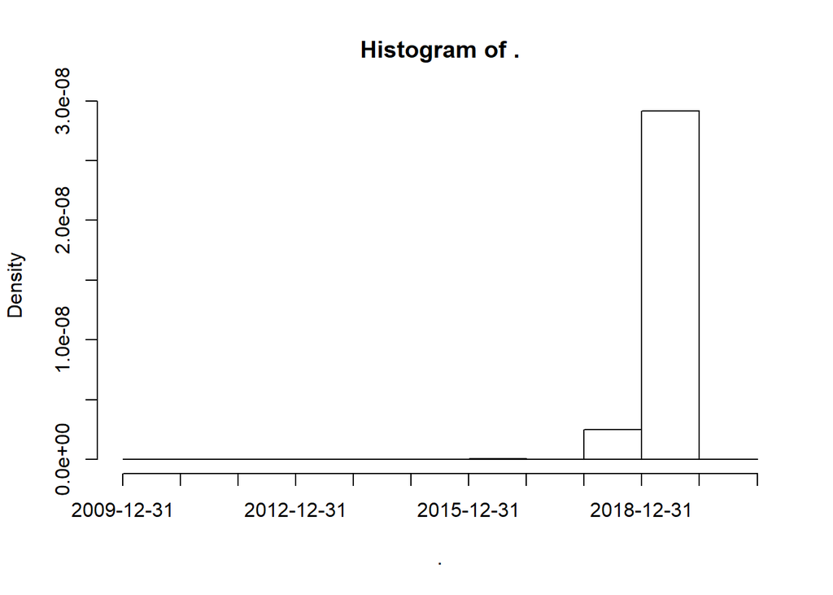

```r
data19_old <- data19 %>% filter(STREET_ADDRESS %in% data18$STREET_ADDRESS)

data19_old %>% filter(YEAR == 2019) %>% pull(CO_ISSUE_DT) %>% hist("years")
```

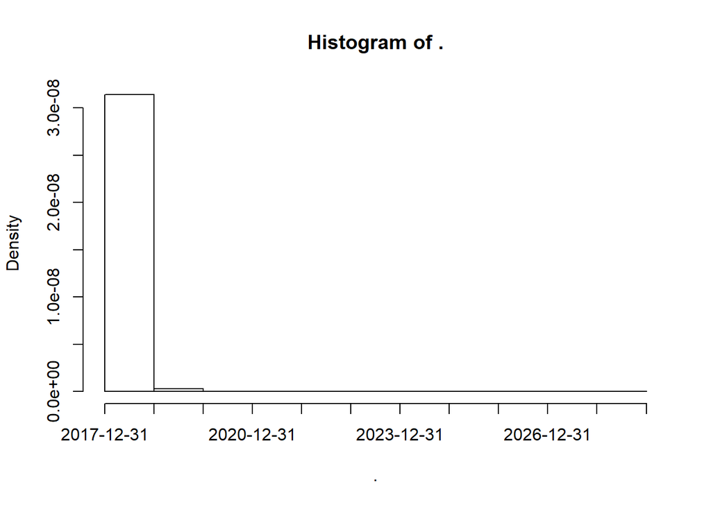

```r
data19_old %>% filter(YEAR == 2018) %>% pull(CO_ISSUE_DT) %>% hist("years")
```

(one address with very incorrect CO date in the future)

The next steps are to:

- Geocode data19
- Standardize addresses and APNs in data19
- Ensure same has been done for data18
- Merge data19 to data18, making sure that identical projects become linked

# Geocoding

My approach to geocoding is:

- All records get a MTC ID
- Connect to Stanford VPN, then log in at https://locator.stanford.edu/arcgis/rest/services. Use Claudia Engel’s functions https://github.com/cengel/ArcGIS_geocoding.
- Spatial join geocoded lat/long to parcels.
- Check if joined parcel APN matches APN on record. Yeses go to “completed” pile. Nos go to “triage 1”.
- All records with unsuccessful address geocoding, try matching APN to available APNS. For successful matches, retrieve MTC/ABAG address associated with the APN, and compare to recorded address with loose string match. If score is above X, then reset recorded address to geocodable address and move to “completed”. The rest go to “triage 2”.
- All remaining unsuccessful matches go to “triage 3”.
- The three triage piles need human review. Fields that need to be manually edited are edited in a new duplicated field.

Retrieve geocoding functions and token. I recommend getting a new token every time at https://locator.stanford.edu/arcgis/tokens/.

```r
source("https://raw.githubusercontent.com/cengel/ArcGIS_geocoding/master/SUL_gcFunctions.R")

# test_adr <- paste(data1417$address[1:10],data1417$jurisdictn[1:10],"CA")

myToken <- "5CCr4VPXNnw46Ui3B66662AA9hB6YeIjv3C6A5Qxn--xh0IxDO7Kq2qlT_j8jBEX"

# test <- do.call(
#   "rbind",
#   lapply(test_adr, function(x) geocodeSL(x, myToken))
# )
#
# leaflet(test) %>%
#   addTiles() %>%
#   addMarkers(
#     lat = ~lat,
#     lng = ~lon
#   )
```

## Geocode all data1417 to compare with MTC’s geocoded results

Spot issues encountered:

- 2367, “3545 O’Conner Dr. Lafayette CA”, caused problem with ’, so added str_replace_all removing punctuation
- 14124, “831 835 837 839 843 845 847 849 853 855 857 859 861 863 Liana Drive Bellvue`\n`823 825 827 829 831 833 835 837 839 843 845 849 851 853 855 857 859 861 863 Liana Drive Bellvue Sonoma Unincorporated CA”, manually set to “831 Liana Drive Bellvue Sonoma CA 95403”

```r
adr <-
  paste(
    data1417$address,
    data1417$jurisdictn,
    "CA",
    data1417$zip
  ) %>%
  str_replace_all("[[:punct:]]| NULL","")

adr[14124] <- "831 Liana Drive Bellvue Sonoma CA 95403"

# geocode1417 <- NULL
# # for(x in 14124:length(adr)){
# for(x in 1:length(adr)){
#   geocode1417 <-
#     geocode1417 %>%
#     rbind(geocodeSL(adr[x], myToken))
#
#   if(x%%100==0){
#     print(x)
#     saveRDS(geocode1417,"geocode1417.rds")
#   }
# }
# saveRDS(geocode1417,"geocode1417.rds")
geocode1417 <- readRDS("geocode1417.rds")

# rough % successful matches
sum(!duplicated(geocode1417$matchAddr))/nrow(geocode1417)
```

```
## [1] 0.6485246
```

```r
# % nas
sum(is.na(geocode1417$lon))/nrow(geocode1417)
```

```
## [1] 0.05572217
```

```r
# % locality
sum(geocode1417$addressType == "Locality")/nrow(geocode1417)
```

```
## [1] 0.1047058
```

```r
# % zipcodes
sum(geocode1417$addressType == "Postal")/nrow(geocode1417)
```

```
## [1] 0.1462846
```

```r
# % street address
sum(geocode1417$addressType == "StreetAddress")/nrow(geocode1417)
```

```
## [1] 0.3394794
```

```r
geocode1417 <-
  geocode1417 %>%
  cbind(
    adr %>% as.data.frame() %>% rename(adr = "."),
    data1417
  )
```

## Geocode data18, new records

```r
adr <-
  paste(
    data18_new$STREET_ADDRESS,
    data18_new$JURS_NAME,
    "California"
  ) %>%
  str_replace_all("[[:punct:]]","")

# adr[14124] <- "831 Liana Drive Bellvue Sonoma CA 95403"

# geocode18 <- NULL
# # for(x in 14124:length(adr)){
# for(x in 1:length(adr)){
#   geocode18 <-
#     geocode18 %>%
#     rbind(geocodeSL(adr[x], myToken))
#
#   if(x%%100==0){
#     print(x)
#     saveRDS(geocode18,"geocode18.rds")
#   }
# }
# saveRDS(geocode18,"geocode18.rds")
geocode18 <- readRDS("geocode18.rds")

# rough % successful matches
sum(!duplicated(geocode18$matchAddr))/nrow(geocode18)
```

```
## [1] 0.4100695
```

```r
# % nas
sum(is.na(geocode18$lon))/nrow(geocode18)
```

```
## [1] 0.0002242655
```

```r
# % locality
sum(geocode18$addressType == "Locality")/nrow(geocode18)
```

```
## [1] 0.4855349
```

```r
# % zipcodes
sum(geocode18$addressType == "Postal")/nrow(geocode18)
```

```
## [1] 0
```

```r
# % street address
sum(geocode18$addressType == "StreetAddress")/nrow(geocode18)
```

```
## [1] 0.2016147
```

```r
geocode18 <-
  geocode18 %>%
  cbind(
    adr %>% as.data.frame() %>% rename(adr = "."),
    data18_new
  )
```

## Geocode data19

Spot issues encountered:

- 2024, “251 Summit Dr `\r`A CORTE MADERA CA”, remove `\r`

```r
adr <-
  paste(data19$STREET_ADDRESS,data19$JURS_NAME,"CA") %>%
  str_replace_all("[[:punct:]]","") %>%
  str_replace_all("\\n","") %>%
  str_replace_all("\\r","")

# geocode1819 <- NULL
# # for(x in 14124:length(adr)){
# for(x in 2024:length(adr)){
#   geocode19 <-
#     geocode19 %>%
#     rbind(geocodeSL(adr[x], myToken))
#
#   if(x%%100==0){
#     print(x)
#     saveRDS(geocode19,"geocode19.rds")
#   }
# }
# saveRDS(geocode19,"geocode19.rds")
geocode19 <- readRDS("geocode19.rds")

# rough % successful matches
sum(!duplicated(geocode19$matchAddr))
```

```
## [1] 10971
```

```r
sum(!duplicated(geocode19$matchAddr))/nrow(geocode19)
```

```
## [1] 0.3554627
```

```r
# % nas
sum(is.na(geocode19$lon))/nrow(geocode19)
```

```
## [1] 0.0001296008
```

```r
# % locality
sum(geocode19$addressType == "Locality")/nrow(geocode19)
```

```
## [1] 0.4900855
```

```r
# % street address
sum(geocode19$addressType == "StreetAddress")/nrow(geocode19)
```

```
## [1] 0.1853616
```

# Check current mapping of data1417

This is the mapping that MTC has already done, with a lot of manual work.

Focus on SMC to start.

```r
smc_data18 <-
  data18 %>%
  filter(CNTY_NAME == "San Mateo")

leaflet() %>%
  addTiles() %>%
  addMarkers(
    data = smc_data18,
    lat = ~MTC_LAT,
    lng = ~MTC_LONG
  )
```

[interactive chart not shown]

This method shows places that have been geocoded to somewhere other than SMC. It could be the case that the original raw data incorrectly stated the project was in SMC, but I find that pretty unlikely since this data was collected from individual jurisdictions. This method could be useful to systematize as a constraining factor on what possible parcels/addresses could be the “correct recipient” of a record, if we are confident that the city or county listing is correct.

# Save

```r
save.image("housing.Rdata")
# load("housing.Rdata")
```